# 18_Diffusion

**Diffusion Models**

By Prof. Seungchul Lee  
http://iailab.kaist.ac.kr/  
Industrial AI Lab at KAIST

Table of Contents

Source

- CS480/680 Intro to Machine Learning
  - Lecture 21: Diffusion Models
  - By Prof. Pascal Poupart at Univ. of Waterloo
  - https://cs.uwaterloo.ca/~ppoupart/teaching/cs480-winter23/
- CS 198-126: Modern Computer Vision Fall 2022
  - Lecture 12: Diffusion Models
  - By Aryan Jain at UC Berkeley
  - https://ml.berkeley.edu/decal/modern-cv
- Diffusion Model 수학이 포함된 tutorial
  - by 권민기 (연세대 석박통합과정)
  - YouTube: https://youtu.be/uFoGaIVHfoE?si=-ockWi1PgdQi0iYU
- Diffusion models from scratch in Pytorch
  - Youtube: https://youtu.be/a4Yfz2FxXiY?si=SwR77vNBvHnWWioZ
- [1] Denoising Diffusion Probabilistic Models
  - Ho, J., Jain, A., & Abbeel, P. (2020). Denoising diffusion probabilistic models. Advances in neural information processing systems, 33, 6840-6851.

# 1. Diffusion Models

- Diffusion models are generative models that learn to generate samples by gradually transforming noise (latent input) to a data sample.

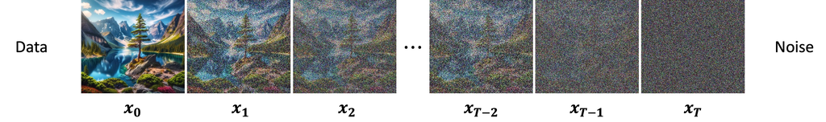

- Fundamentally there are two processes:
  - Forward process: Given input image $x_0$, gradually add Gaussian noise to it for $T$ steps.
  - Reverse process: A neural network is trained to recover this original data by reversing the noising process.
- After training, we can generate new samples by denoising noise (latent input) with the trained neural network.
- Assumption : The transition between timesteps is Markovian, i.e., the current timestep only depends on the previous timestep.

# 2. Diffusion Process

## 2.1. Forward Diffusion Process

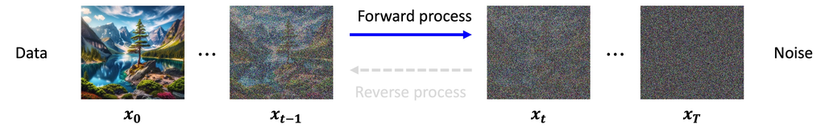

The forward process iteratively adds noise to the image. Each noise added is considered a Gaussian, and thus can be written as

$$q(x_t | x_{t-1}) = N (x_t;\sqrt{1-\beta_t}x_{t-1}, \beta_t \mathbb{I}), $$

where $\beta_t$ is a noise scheduler.

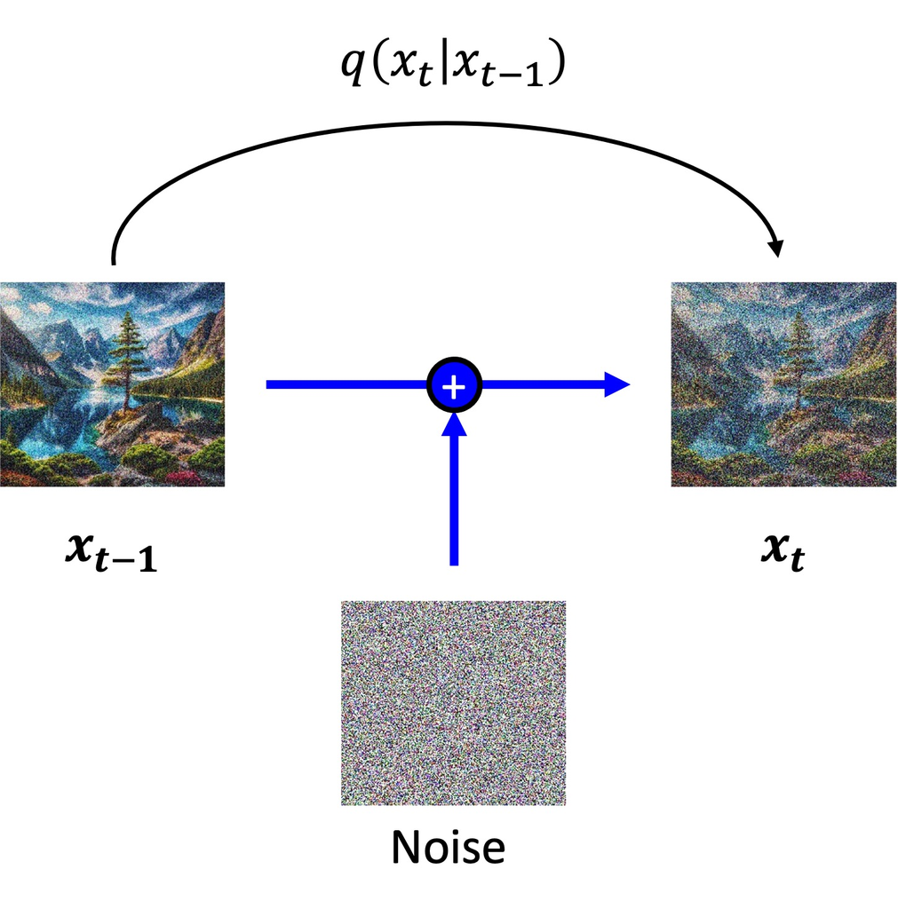

For a given original image $x_{0}$, this process is repeated $T$ steps, until the image becomes an isotropic Gaussian $N(0, 1)$. Due to the Markovian property, we can express these transitions as a chain of individual transitions from time $0$ to $t$ as

$$q(x_t | x_{0}) = q(x_t | x_{t-1}) q(x_{t-1} | x_{t-2}) \cdots q(x_2 | x_{1}) q(x_1 | x_{0}). $$

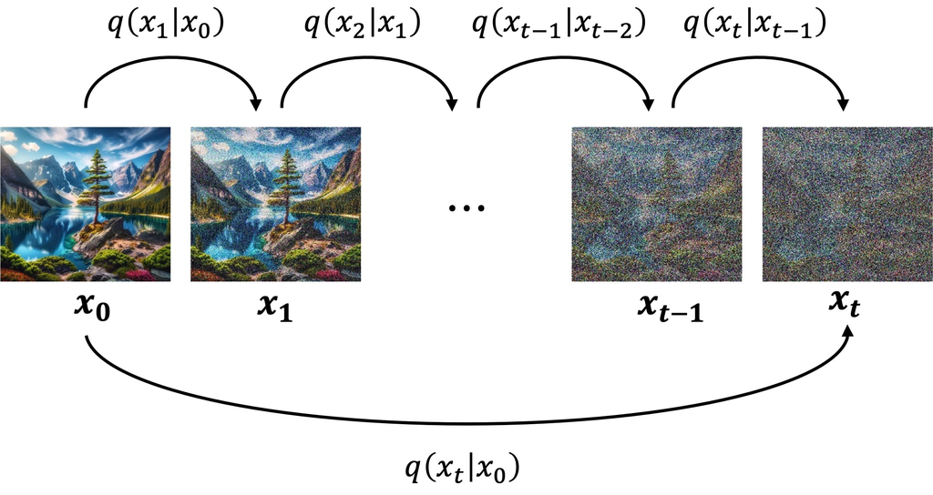

Because the joint distribution of Gaussians is also Gaussian, our forward process distribution for a given input image $x_0$ at time $t$ is

where $\alpha_t = 1- \beta_t$, $\bar{\alpha}_t = \prod_{s=0}^{t} \alpha_s$, and $\epsilon \sim N (0,1).$

By using the reparametrization trick we can write $x_{t}$ as

$$x_t = \sqrt{\bar{\alpha}_t}*x_0 + \sqrt{1-\bar{\alpha}_t}*\epsilon ,$$

enabling tractable closed-form sampling at any timestep.

## 2.2. Reverse Diffusion Process

- *Disclaimer: Intermediary steps for derivation will not be provided in this tutorial for simplicity. Please refer to the original paper for full details*.

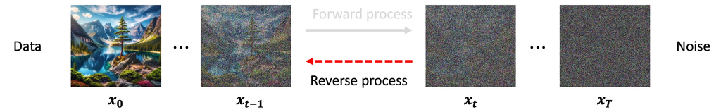

The goal of diffusion models is to learn the reverse process. Because the reverse process (forward process posterior) $q(x_{t-1}|x_t)$ is inherently intractable, we start by conditioning this distribution on the input image $x_0$, i.e., $q(x_{t-1}|x_t, x_0)$. We can write out this distribution as

$$q(x_{t-1}|x_t,x_0) = (N (x_{t-1}; \tilde{\mu}(x_t,x_0) , \tilde{\beta}_t ).$$

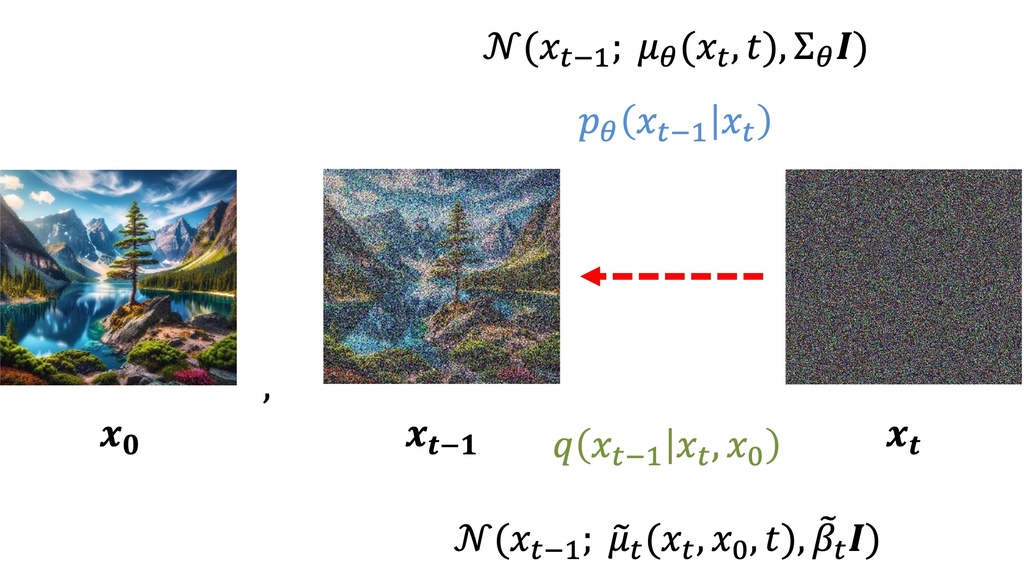

Using the equation derived for the forward process. ($x_t = \sqrt{\bar{\alpha}_t}*x_0 + \sqrt{1-\bar{\alpha}_t}*\epsilon$), we can express $\tilde{\mu}(x_t,x_0)$ and $\tilde{\beta}_t$ as

$$ \tilde{\mu}(x_t,x_0) = \frac{1}{\sqrt{\alpha_t}} \left( x_t - \frac{1-\alpha_t}{ \sqrt{1-\bar{\alpha}_t}} \epsilon_t \right) $$ and $$ \tilde{\beta}_t = \frac{1-\bar{\alpha}_{t-1}}{1-\bar{\alpha}_t} \beta_t .$$

Here, we attempt to learn this distribution (learn $\tilde{\mu}(x_t,x_0)$ and $\tilde{\beta}_t$) with a neural network $q_{\theta}(x_{t-1}|x_t)$ by minimizing the distance$^*$ between $q(x_{t-1}|x_t, x_0)$ and $q_{\theta}(x_{t-1}|x_t)$. In other words, we are learning $\mu_{\theta}(x_t,x_0)$ and $\Sigma_{\theta}$ (the mean and variance of the forward process *posterior*). Hence our loss can be formulated as the following:

- $^*$*Note: Additional terms of the original loss function are ommited for simplicity in this tutorial*.

$$ L_t = \mathbb{E} \left[ D_{KL}( q(x_{t-1}|x_t, x_0) || q_{\theta}(x_{t-1}|x_t)) \right] $$

where $D_{KL}$ refers to the KL-divergence (a distance metric for distributions).

Writing out $L_t$ (by definition of KL-divergence), we have

$$ L_t = \mathbb{E} \left[ \frac{{(1-\alpha_t)}^2}{2 \alpha_t (1-\bar{\alpha}_t) \lVert \Sigma_{\theta} \rVert _2} \lVert \epsilon_t - \epsilon_{\theta} (\sqrt{\bar{\alpha}_t}x_0 + \sqrt{1-\bar{\alpha}_t} \epsilon_t, t) \rVert ^2\right]. $$

The authors of [1] show that the training process works better with a simplified objective (by ignoring the weighting term)

$$ L_t = \mathbb{E} \left[ \lVert \epsilon_t - \epsilon_{\theta} (\sqrt{\bar{\alpha}_t}x_0 + \sqrt{1-\bar{\alpha}_t} \epsilon_t, t) \rVert ^2\right] $$

or

$$ L_t = \mathbb{E} \left[ \lVert \epsilon_t - \epsilon_{\theta} (x_t, t) \rVert ^2\right] . $$

Minimizing this training objective allows the neural network to learn the reverse process.

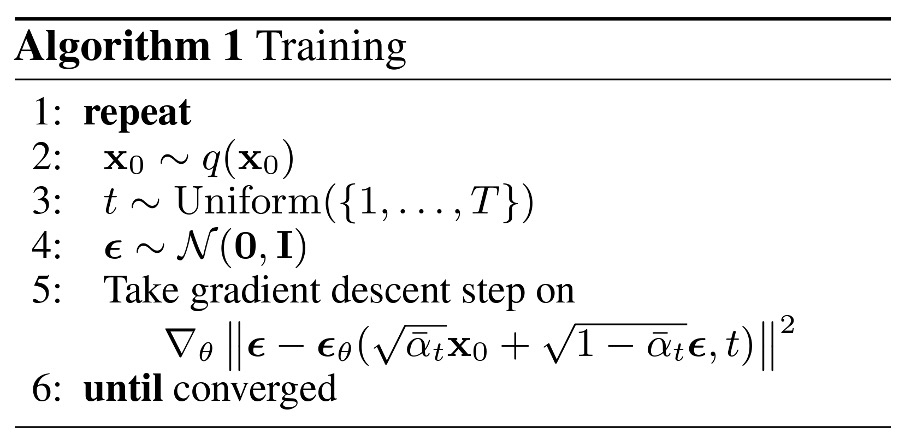

## 2.3. Sampling from the Trained Model

Once $q_{\theta}(x_{t-1}|x_t)$ is learned ($\mu_{\theta}(x_t,x_0)$ and $\Sigma_{\theta}$ are learned), we can sample from this distribution for $T$ steps to generate samples.

$$q_{\theta}(x_{t-1}|x_t) = N \left( x_{t-1}; \frac{1}{\sqrt{\alpha_t}} \left( x_t - \frac{1-\alpha_t}{ \sqrt{1-\bar{\alpha}_t}} \epsilon_{\theta} \right) , \Sigma_{\theta} \right).$$

The authors of [1] show that learning a diagonal variance $\Sigma_{\theta}$ leads to unstable training and poor sampling quality, and thus fixed $\Sigma_{\theta} = \beta_t$ instead of making them learnable. Thus using the reparametrization trick, we can express $x_{t-1}$ given $x_t$ as

$$x_{t-1} = \frac{1}{\sqrt{\alpha_t}} \left( x_t - \frac{1-\alpha_t}{\sqrt{1-\bar{\alpha}_t}} \epsilon_{\theta}(x_t,t) \right) + \sigma_t \textbf{z} ,$$

where $\textbf{z} \sim N(0,1)$. We repeat this process for $t=T,T-1, ...,1, 0.$

# 3. Diffusion with Fashion MNIST

```python
import tensorflow as tf
import numpy as np
import matplotlib.pyplot as plt
```

```python
(train_x, train_y), _ = tf.keras.datasets.fashion_mnist.load_data()

X_train = train_x[train_y.squeeze() == 7]
X_train = (X_train / 127.5) - 1.0

print('train_images :', train_x.shape)
```

```
train_images : (60000, 28, 28)
```

## 3.1. Forward Process Implementation

- First define the total timesteps $T$ and the noise scheduler $\beta_t$, as a simple linear scheduler.

```python
T = 50
beta_schedule = np.linspace(0, 1.0, T+1)
```

- Use the tractable closed form for $x_t$ derived above to sample noisy images $x_t$.

$$x_t = \sqrt{\bar{\alpha}_t}*x_0 + \sqrt{1-\bar{\alpha}_t}*\epsilon .$$

```python
def forward_diffusion (x0, t):
    alphas = 1. - beta_schedule
    alpha_bars = tf.math.cumprod(alphas, axis=0)

    epsilon = np.random.normal(size=x0.shape)

    alpha_bar_t = tf.gather(alpha_bars, t)
    alpha_bar_t = np.reshape(alpha_bar_t,(-1,1,1))
    noisy_image = np.sqrt(alpha_bar_t)*x0 + np.sqrt(1 - alpha_bar_t)*epsilon

    return noisy_image, epsilon
```

## 3.2. Model architecture

```python
def time_embedding(x_img, x_ts, n_channels):
    x_parameter = tf.keras.layers.Conv2D(n_channels, kernel_size=3, padding='same')(x_img)
    x_parameter = tf.keras.layers.Activation('relu')(x_parameter)

    time_parameter = tf.keras.layers.Dense(n_channels)(x_ts)
    time_parameter = tf.keras.layers.Activation('relu')(time_parameter)
    time_parameter = tf.keras.layers.Reshape((1, 1, n_channels))(time_parameter)
    x_parameter = x_parameter * time_parameter

    x_out = tf.keras.layers.Conv2D(n_channels, kernel_size=3, padding='same')(x_img)
    x_out = x_out + x_parameter
    x_out = tf.keras.layers.BatchNormalization()(x_out)
    x_out = tf.keras.layers.Activation('relu')(x_out)

    return x_out

def unet():
    x_input = tf.keras.layers.Input(shape=(28, 28, 1), name='x_input')

    x_ts_input = tf.keras.layers.Input(shape=(1,), name='x_ts_input')
    x_ts = tf.keras.layers.Dense(192)(x_ts_input)
    x_ts_ln = tf.keras.layers.BatchNormalization()(x_ts)
    x_ts_out = tf.keras.layers.Activation('relu')(x_ts_ln)

    x28_down = time_embedding(x_input, x_ts_out, 16)
    block1_down = tf.keras.layers.MaxPool2D(2)(x28_down)

    x14_down = time_embedding(block1_down, x_ts_out, 32)
    block2_down = tf.keras.layers.MaxPool2D(2)(x14_down)

    x7_down = time_embedding(block2_down, x_ts_out, 64)

    mlp_input = tf.keras.layers.Flatten()(x7_down)
    mlp_concat = tf.keras.layers.Concatenate()([mlp_input, x_ts_out])
    mlp = tf.keras.layers.Dense(7*7*64)(mlp_concat)
    mlp_ln = tf.keras.layers.BatchNormalization()(mlp)
    mlp_out = tf.keras.layers.Activation('relu')(mlp_ln)
    mlp_out = tf.keras.layers.Reshape((7, 7, 64))(mlp_out)

    x7_up_input = tf.keras.layers.Concatenate()([mlp_out, x7_down])
    x7_up = time_embedding(x7_up_input, x_ts_out, 64)
    block1_up = tf.keras.layers.Conv2DTranspose(64, (4,4),strides=(2,2),
                                                padding='same')(x7_up)

    x14_up_input = tf.keras.layers.Concatenate()([block1_up, x14_down])
    x14_up = time_embedding(x14_up_input, x_ts_out, 32)
    block2_up = tf.keras.layers.Conv2DTranspose(32, (4,4),strides=(2,2),
                                                padding='same')(x14_up)

    x28_up_input = tf.keras.layers.Concatenate()([block2_up, x28_down])
    x28_up = time_embedding(x28_up_input, x_ts_out, 16)

    x_out = tf.keras.layers.Conv2D(1, kernel_size=1, padding='same')(x28_up)
    model = tf.keras.models.Model([x_input, x_ts_input], x_out)
    return model

model = unet()

# model.summary()
```

```python
optimizer = tf.keras.optimizers.Adam(learning_rate=0.0008)
loss_func = tf.keras.losses.MeanSquaredError()
model.compile(loss=loss_func, optimizer=optimizer)
```

## 3.3. Training (learning the reverse process)

Step 1: Sample $x_0$ from dataset ($x_0 \sim p(x)$) and add noise from uniformly sampled $t$ ($ t \sim$ Uniform$( \{ 1, ..., T \}))$.

Step 2: Feed through neural network and minimize loss

$$ L_t = \mathbb{E} \left[ \lVert \epsilon_t - \epsilon_{\theta} (x_t, t) \rVert ^2\right] . $$

```python
# Training loop

n_batch = 64
n_iter = 1000
n_print = 200

for e in range(n_iter):
    x_img = X_train[np.random.randint(len(X_train), size=n_batch)]
    ts = np.random.randint(0, T, size=len(x_img))
    x_t, epsilon = forward_diffusion(x_img, ts)

    loss = model.train_on_batch([x_t, ts], epsilon)

    if e % n_print == 0:
        print(f"Iteration {e}/{n_iter}. Loss: {loss:.5f}")
```

```
Iteration 0/1000. Loss: 1.80499
Iteration 200/1000. Loss: 0.16916
Iteration 400/1000. Loss: 0.11770
Iteration 600/1000. Loss: 0.09738
Iteration 800/1000. Loss: 0.08678
```

## 3.4. Reverse Diffusion (sampling process)

Step 1: Start from isotropic noise ($N(0,1)$), and predict $\epsilon_{\theta}(x_t, t)$ with neural network.

Step 2: Sample from distribution

$$q_{\theta}(x_{t-1}|x_t) = N \left( x_{t-1}; \frac{1}{\sqrt{\alpha_t}} \left( x_t - \frac{1-\alpha_t}{ \sqrt{1-\bar{\alpha}_t}} \epsilon_{\theta} \right) , \tilde{\beta}_{\theta} \right)$$

to get

$$x_{t-1} = \frac{1}{\sqrt{\alpha_t}} \left( x_t - \frac{1-\alpha_t}{\sqrt{1-\bar{\alpha}_t}} \epsilon_{\theta}(x_t,t) \right) + \sigma_t \textbf{z} ,$$

using the reparametrization trick.

Step 3: Repeat Steps 1 and 2 until $t=0$.

```python
def reverse_diffusion(n_sample):
    x_t = np.random.normal(size=(n_sample, 28, 28, 1))

    alphas = 1. - beta_schedule
    alpha_bars = tf.math.cumprod(alphas, axis=0)

    for t in range(T-1):

        t = T - t-1

        e_t = model.predict([x_t, np.full((n_sample), t)], verbose=0)
        x_t_1 = (1/np.sqrt(alphas[t]))*(x_t - ((1-alphas[t])/np.sqrt(1-alpha_bars[t])*e_t))

        sigma_t = np.sqrt(beta_schedule[t])
        z = np.random.normal(size=(n_sample, 28, 28, 1))

        if t>1:
          x_t = x_t_1 + sigma_t * z
        else:
          x_t = x_t_1

    x0 = x_t

    return x0
```

## 3.5. Visualize the Results

```python
x_generate = reverse_diffusion(10)
```

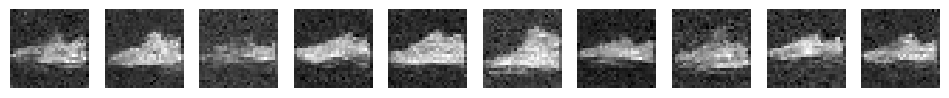

```python
plt.figure(figsize = (12, 3))
for i in range(x_generate.shape[0]):
    plt.subplot(1, 10, i + 1)
    plt.imshow(x_generate[i].reshape((28, 28)), 'gray', interpolation = 'nearest')
    plt.axis('off')

plt.show()
```

```python
%%javascript
$.getScript('https://kmahelona.github.io/ipython_notebook_goodies/ipython_notebook_toc.js')
```